# This is my work in R

August 23, 2022

date: August 23, 2022

Abstract

This is an example of an abstract in a paper. This is an example of an abstract in a paper.This is an example of an abstract in a paper. This is an example of an abstract in a paper.This is an example of an abstract in a paper.This is an example of an abstract in a paper.This is an example of an abstract in a paper.

# Introduction

This is just my intro to my nice paper. This is just my intro to my nice paper.This is just my intro to my nice paper. This is just my intro to my nice paper.This is just my intro to my nice paper. This is just my intro to my nice paper.This is just my intro to my nice paper. This is just my intro to my nice paper.This is just my intro to my nice paper. This is just my intro to my nice paper.This is just my intro to my nice paper. This is just my intro to my nice paper.

This is just my intro to my nice paper. This is just my intro to my nice paper.This is just my intro to my nice paper. This is just my intro to my nice paper.This is just my intro to my nice paper. This is just my intro to my nice paper.This is just my intro to my nice paper. This is just my intro to my nice paper.

# 1 Exploring Tables

Another section. I will use a footnot now [^1]. I will soon use cross-ref.I will soon use cross-ref.I will soon use cross-ref.I will soon use cross-ref. I will soon use cross-ref. I will soon use cross-ref.I will soon use cross-ref.I will soon use cross-ref.I will soon use cross-ref.I will soon use cross-ref. I will soon use cross-ref. I will soon use cross-ref.

I will soon use cross-ref.I will soon use cross-ref: as we see in Section 1.1.

## 1.1 Exploring Categorical Data

Here, I continue doing this nice work, I hope you like it and read it. It has been a very hard work.Here, I continue doing this nice work, I hope you like it and read it. It has been a very hard work.Here, I continue doing this nice work, I hope you like it and read it. It has been a very hard work.Here, I continue doing this nice work, I hope you like it and read it. It has been a very hard work.Here, I continue doing this nice work, I hope you like it and read it. It has been a very hard work.Here, I continue doing this nice work, I hope you like it and read it. It has been a very hard work.

I hope you like it and read it. It has been a very hard work.Here, I continue doing this nice work, I hope you like it and read it. It has been a very hard work.Here, I continue doing this nice work, I hope you like it and read it. It has been a very hard work.Here, I continue doing this nice work, I hope you like it and read it. It has been a very hard work.Here, I continue doing this nice work, I hope you like it and read it. It has been a very hard work.

You can see the statistics of categorical variables in Table 1.1.

Table 1.1: This is a table

| Democracy Index | count | pct | pct_cumm |
| --- | --- | --- | --- |
| veryLow | 53 | 33.76 | 33.76 |
| low | 31 | 19.75 | 53.50 |
| medium | 53 | 33.76 | 87.26 |
| good | 0 | 0.00 | 87.26 |
| veryGood | 20 | 12.74 | 100.00 |

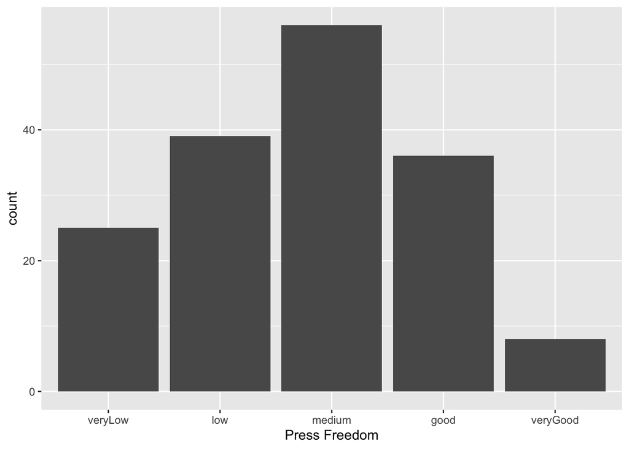

Figure 1.1: Freedom of Press in the world

## 1.2 Exploring Numerical Data

Here, I continue doing this nice work, I hope you like it and read it. It has been a very hard work.Here, I continue doing this nice work, I hope you like it and read it. It has been a very hard work.Here, I continue doing this nice work, I hope you like it and read it. It has been a very hard work.Here, I continue doing this nice work, I hope you like it and read it. It has been a very hard work.Here, I continue doing this nice work, I hope you like it and read it. It has been a very hard work.Here, I continue doing this nice work, I hope you like it and read it. It has been a very hard work.Here, I continue doing this nice work, I hope you like it and read it. It has been a very hard work.Here, I continue doing this nice work, I hope you like it and read it. It has been a very hard work.Here, I continue doing this nice work, I hope you like it and read it. It has been a very hard work.

Here, I continue doing this nice work, I hope you like it and read it. It has been a very hard work.Here, I continue doing this nice work, I hope you like it and read it. It has been a very hard work.

Table 1.2: Stat summary for nummeric vars

| Variable | N | Mean | Std. Dev. | Min | Pctl. 25 | Pctl. 75 | Max |
| --- | --- | --- | --- | --- | --- | --- | --- |
| DemocracyIndex | 157 | 2.38 | 1.3 | 1 | 1 | 3 | 5 |
| mili_pctGDP | 166 | 2.07 | 1.55 | 0.2 | 1.1 | 2.48 | 10 |

In the Table 1.2, you realize that the mean of military expenditure is **2.0722892**.

It would be good to see a boxplot, check Figure 1.2 below.

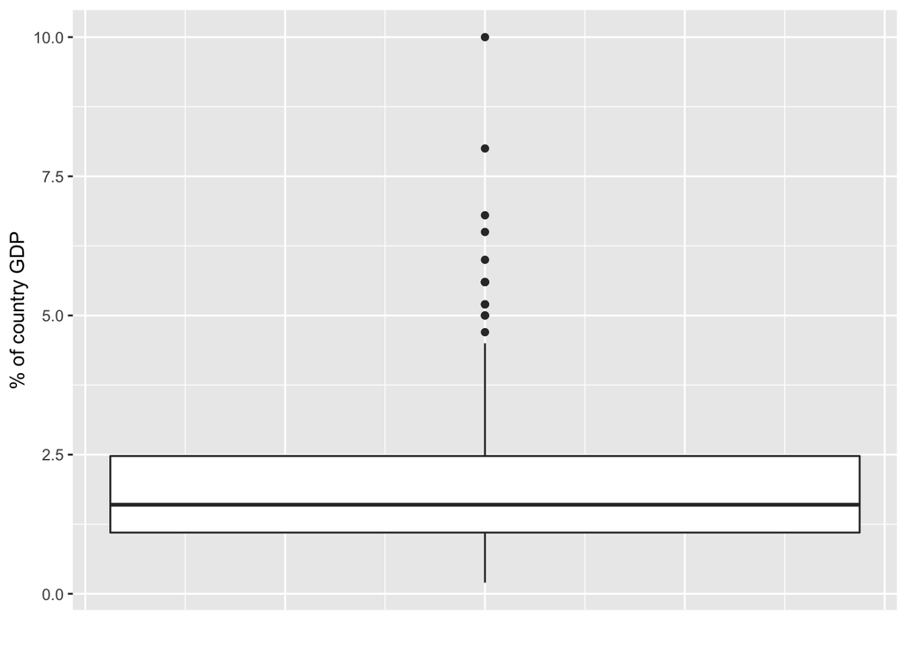

Figure 1.2: Money spent per country on Military stuff

Boxplots were introduced by (Tukey, 1977).

# 2 My Regression

Several times we need regression.

This is a nice summary for two regressions, as shown in Table 2.1:

Table 2.1: Models for Military Expenditure

|  | Model 1 | Model 2 |
| --- | --- | --- |
| (Intercept) | 3.083*** | 2.730*** |
|  | (0.245) | (0.291) |
| DemocracyIndex | −0.423*** | −0.535*** |
|  | (0.090) | (0.128) |
| IndexofEconomicFreedom |  | 0.230 |
|  |  | (0.149) |
| Num.Obs. | 157 | 154 |
| R2 | 0.124 | 0.126 |
| R2 Adj. | 0.119 | 0.114 |
| AIC | 569.2 | 553.0 |
| BIC | 578.3 | 565.2 |
| Log.Lik. | −281.577 | −272.510 |
| F | 22.008 | 10.857 |
| RMSE | 1.45 | 1.42 |

+ p < 0.1, * p < 0.05, ** p < 0.01, *** p < 0.001

You can also do this: You can also do this:You can also do this:You can also do this: You can also do this:You can also do this:You can also do this: You can also do this:You can also do this:You can also do this: You can also do this:You can also do this:You can also do this: You can also do this:You can also do this:You can also do this: You can also do this:You can also do this:You can also do this: You can also do this:You can also do this:You can also do this: You can also do this:You can also do this:

Table 2.2: Models for Military Expenditure

|  | Model 1 | Model 2 |
| --- | --- | --- |
| Democracy | −0.423*** | −0.535*** |
|  | (0.090) | (0.128) |
| Economic Freedom |  | 0.230 |
|  |  | (0.149) |
| Constant | 3.083*** | 2.730*** |
|  | (0.245) | (0.291) |
| Num.Obs. | 157 | 154 |
| R2 | 0.124 | 0.126 |
| R2 Adj. | 0.119 | 0.114 |
| AIC | 569.2 | 553.0 |
| BIC | 578.3 | 565.2 |
| Log.Lik. | −281.577 | −272.510 |
| F | 22.008 | 10.857 |
| RMSE | 1.45 | 1.42 |

+ p < 0.1, * p < 0.05, ** p < 0.01, *** p < 0.001

I hope you like what you see in the Table 2.1 and in Table 2.2. You can learn more on regression in other book (Petrie, 2016, pp. 150–160).

# 3 Other plots

## 3.1 A word cloud

Let me show a nice word cloud.Let me show a nice word cloud.Let me show a nice word cloud.Let me show a nice word cloud.Let me show a nice word cloud.Let me show a nice word cloud.Let me show a nice word cloud.Let me show a nice word cloud.Let me show a nice word cloud.Let me show a nice word cloud.Let me show a nice word cloud.Let me show a nice word cloud. Let me show a nice word cloud.Let me show a nice word cloud.Let me show a nice word cloud.Let me show a nice word cloud.Let me show a nice word cloud.Let me show a nice word cloud.

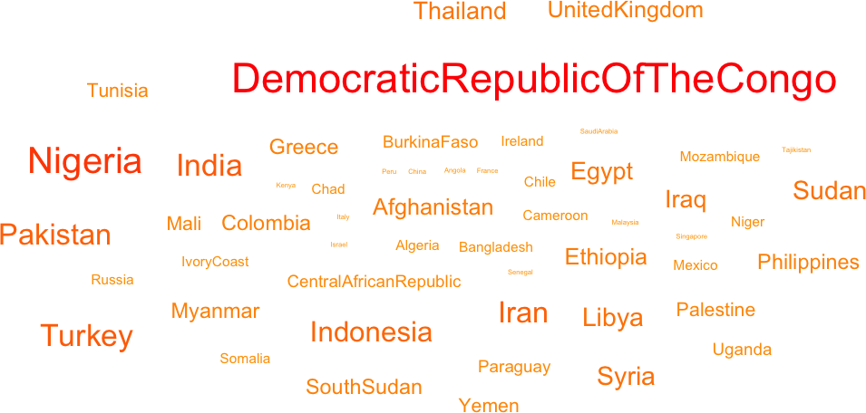

Figure 3.1: Nations by presence of rebel movements.

Above you see our Figure 3.1. Here, I continue doing this nice work, I hope you like it and read it. It has been a very hard work.Here, I continue doing this nice work, I hope you like it and read it. It has been a very hard work.Here, I continue doing this nice work, I hope you like it and read it. It has been a very hard work.Here, I continue doing this nice work, I hope you like it and read it. It has been a very hard work.Here, I continue doing this nice work, I hope you like it and read it. It has been a very hard work.Here, I continue doing this nice work, I hope you like it and read it. It has been a very hard work.Here, I continue doing this nice work, I hope you like it and read it. It has been a very hard work.Here, I continue doing this nice work, I hope you like it and read it. It has been a very hard work.Here, I continue doing this nice work, I hope you like it and read it. It has been a very hard work.

It has been a very hard work.Here, I continue doing this nice work, I hope you like it and read it.

It has been a very hard work.Here, I continue doing this nice work, I hope you like it and read it. It has been a very hard work.Here, I continue doing this nice work, I hope you like it and read it.

You can read something interesting somewhere else (Lipman, 2022).

## 3.2 A map

Let me show a nice map.Let me show a nice map.Let me show a nice map.Let me show a nice map.Let me show a nice map.Let me show a nice map.Let me show a nice map.Let me show a nice map.Let me show a nice map.Let me show a nice map.Let me show a nice map.Let me show a nice map.

Let me show a nice map.Let me show a nice map.Let me show a nice map.Let me show a nice map.Let me show a nice map.Let me show a nice map.Let me show a nice map.Let me show a nice map.Let me show a nice map.Let me show a nice map.Let me show a nice map.Let me show a nice map.

Let me show a nice map.Let me show a nice map.Let me show a nice map.Let me show a nice map.Let me show a nice map.Let me show a nice map.Let me show a nice map.Let me show a nice map.Let me show a nice map.Let me show a nice map.Let me show a nice map.Let me show a nice map in Figure 3.2.

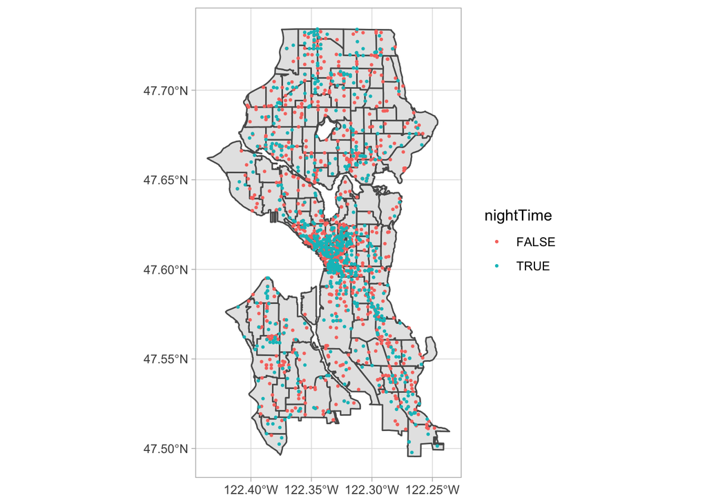

Figure 3.2: Calls to 911 by time of day

Here, I continue doing this nice work, I hope you like it and read it. It has been a very hard work.Here, I continue doing this nice work, I hope you like it and read it. It has been a very hard work.Here, I continue doing this nice work, I hope you like it and read it. It has been a very hard work.Here, I continue doing this nice work, I hope you like it and read it.

Review other authors (Câmara et al., n.d., pp. 120–150; also, see Brunsdon & Comber, 2015) to know more.

# Bibliography

Brunsdon, C., & Comber, L. (2015). *An introduction to R for spatial analysis & mapping*. SAGE.

Câmara, G., Monteiro, A. M., Fucks, S. D., & Sá, M. (n.d.). *Spatial Analysis and GIS: A Primer*. 30.

Lipman, G. (2022). The Art of Wordle. In *Medium*.

Petrie, A. G. (2016). *Introduction to regression and modeling with R*.

Tukey, J. W. (1977). *Exploratory data analysis*. Addison-Wesley Pub. Co.

[^1]: This is a footnote.